# Assessment

2024-11-01

#Data Science for Health and Biomedical Sciences Assessment

## The rise of scabies in Scotland and link to socioeconomic factors

In this paper, I will be examining:

- the relationship (if any) between prescriptions of permethrin and malathion and deprivation status, as measured by SIMD quintile
- the relationship (if any) between prescriptions of permethrin and malathion and overcrowding
- fluctuations in scabies medication prescription over time

*Another alternative if this idea doesn’t work - then another idea would be methadone prescriptions, look at over socioeconomic factors, correlations with other drugs, drug misuse and overdose, etc. Trends over time.*

### Loading required libraries

```r
pacman::p_load(tidyverse,janitor, gt, here, sf, patchwork, purrr)
```

### Data

```r
data_january2024 <- read_csv("https://www.opendata.nhs.scot/dataset/84393984-14e9-4b0d-a797-b288db64d088/resource/d3eaaf84-0f3b-4fb8-9460-e33503095fbe/download/pitc202401.csv") %>%
  clean_names()

gp_practice_jan2024 <- read_csv("https://www.opendata.nhs.scot/dataset/f23655c3-6e23-4103-a511-a80d998adb90/resource/54a6e1e3-98a3-4e78-be0d-1e6d6ebdde1d/download/practice_contactdetails_jan2024-open-data.csv") %>%
  clean_names() %>%
  select(practice_code, data_zone)

datazone_pop <- read_csv("https://www.opendata.nhs.scot/dataset/7f010430-6ce1-4813-b25c-f7f335bdc4dc/resource/c505f490-c201-44bd-abd1-1bd7a64285ee/download/dz2011-pop-est_09092022.csv") %>%
  clean_names()

scottish_index_deprivation <-
  st_read(here("data","SG_ScotInedMultipleDeprivation_2020/SG_SIMD_2020.shp")) %>%
  clean_names()
```

### Selecting and filtering scabies medication data

```r
per_mal_2024 <- data_january2024 %>%
  select(gp_practice, bnf_item_description,paid_quantity) %>%
   filter(str_detect(bnf_item_description, "PERMETH|MALATH"))
#We're specifically looking at trends in permethrin and malathion prescriptions.
```

We’re going to join the data containing prescription information with the dataframe of thedatazones assigned to GP practices, and then to datazone population information.

```r
datazone_pop_clean <- datazone_pop %>%
  filter(year == 2021,
         sex == "All") %>%
  select(data_zone, population = all_ages)
#We want the population for all sexes and all ages in each datazone, to later be able to normalize prescription data.

per_mal_with_gps_2024 <- per_mal_2024 %>%
  left_join(gp_practice_jan2024, by=c("gp_practice" = "practice_code")) %>%
  left_join(datazone_pop_clean, by="data_zone")
```

There are GP practices that have NA -> this is especially the ones allocated “99996”, which are coded from a ‘community pharmacy’, “Unallocated” practice codes are coded 99997, “hospital” 99998. These will be useful in a temporal analysis, but not a location analysis, so for the further location analysis, we can remove them.

```r
per_mal_datazones_allocated_2024 <- per_mal_with_gps_2024 %>%
  filter(!gp_practice %in% c(99996, 99997, 99998))
```

## Scabies prescriptions in deprivation quintiles

We will join the permethrin and malathion prescription data with data on the deprivation of datazones, using the SIMD dataset. We will specifically focusing on the deprivation quintile, and the percentage of people living in overcrowded housing.

```r
per_mal_2024_deprivation <- per_mal_datazones_allocated_2024 %>%
  left_join(scottish_index_deprivation, by="data_zone") %>%
  select(paid_quantity, data_zone, population, quintilev2, house_o_crat) %>%
  mutate(scabies_prescriptions_per_1000 = (paid_quantity*1000/population))

prescriptions_by_quintile <- per_mal_2024_deprivation %>%     filter(!is.na(quintilev2)) %>%
  group_by(quintilev2) %>%
  summarise(`Mean number of prescriptions` =  mean(scabies_prescriptions_per_1000, na.rm=TRUE),
          `Standard deviation` = sd(scabies_prescriptions_per_1000, na.rm=TRUE)) %>%
  rename(`SIMD quintile`=quintilev2)

prescriptions_by_quintile_table <- prescriptions_by_quintile %>%
  gt() %>%
  fmt_number(decimals=1) %>%
  tab_header(
    title = "Permethrin and Malathion prescriptions per 1000 people",
    subtitle = "Averaged over SIMD quintiles")
```

## Prescriptions by quintile (Figure 1)

```r
prescriptions_by_quintile_table
```

Permethrin and Malathion prescriptions per 1000 people

Averaged over SIMD quintiles

| SIMD quintile | Mean number of prescriptions | Standard deviation |
| --- | --- | --- |
| 1.0 | 398.5 | 533.6 |
| 2.0 | 387.0 | 380.4 |
| 3.0 | 408.2 | 490.8 |
| 4.0 | 426.9 | 421.9 |
| 5.0 | 437.9 | 504.8 |

Interestingly, if we look at the above averages, it seems that the prescriptions in the **less** deprived quintiles (1 being most deprived, 5 being the least) had higher average scabies medication prescriptions. This could be due to a number of reasons: - missing data, especially in more deprived areas - lack of knowledge about scabies in more deprived area - better access to scabies medication in less deprived areas (as measurement of prescription is a very indirect method of tracking the disease itself). Additionally, the data for prescriptions have very high standard deviation. It’s therefore difficult to reach any strong conclusions about deprivation and permethrin/malathion prescriptions.

## Prescriptions by quintile (Figure 2)

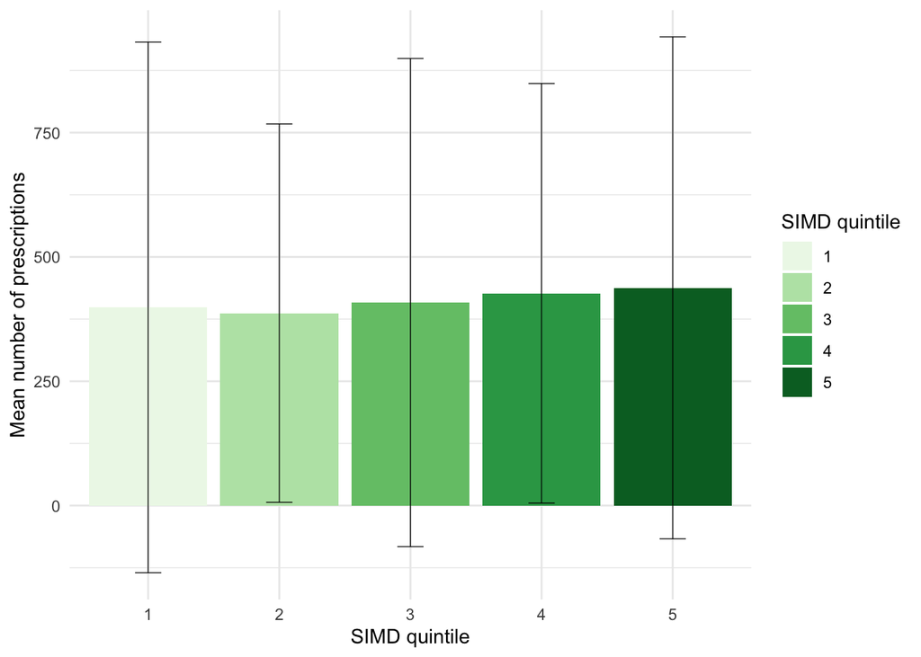

```r
plot_prescriptions_quintile <- as.data.frame(prescriptions_by_quintile) %>%
  mutate(`SIMD quintile` = as.factor(`SIMD quintile`)) %>%
  ggplot(aes(x=`SIMD quintile`, y=`Mean number of prescriptions`, fill=`SIMD quintile`)) +
  geom_col()  +
  geom_errorbar( aes(x=`SIMD quintile`, ymin=`Mean number of prescriptions`- `Standard deviation`, ymax=`Mean number of prescriptions`+ `Standard deviation`), width=0.2, colour="black", alpha=0.8, linewidth=0.3) +
  scale_fill_brewer(palette="Greens") +
  theme_minimal()

plot_prescriptions_quintile
```

```r
#if we add the standard deviations, we see that we likely can't correlate the SIMD quintile with the mean number of prescriptions, as it's too variable.

correlation <- cor.test(per_mal_2024_deprivation$quintilev2, per_mal_2024_deprivation$scabies_prescriptions_per_1000, method="spearman")

correlation
```

```
##
##  Spearman's rank correlation rho
##
## data:  per_mal_2024_deprivation$quintilev2 and per_mal_2024_deprivation$scabies_prescriptions_per_1000
## S = 100493564, p-value = 0.4058
## alternative hypothesis: true rho is not equal to 0
## sample estimates:
##        rho
## 0.02849956
```

```r
#probably find a better correlation calculation but shows only a very weak correlation.
```

## Prescriptions by overcrowding (Figure 3)

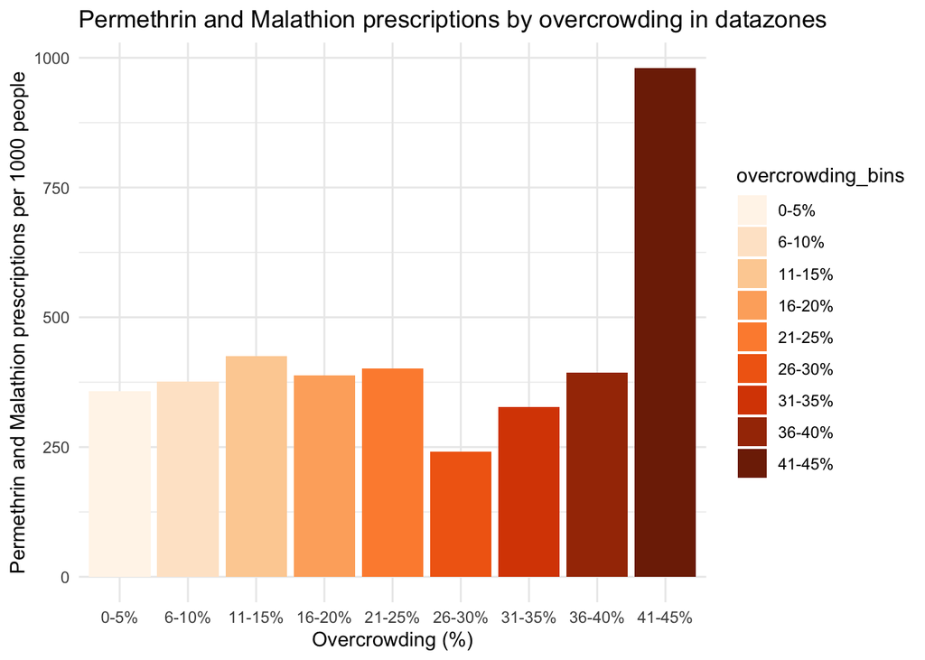

```r
per_mal_2024_deprivation$house_o_crat= as.numeric(sub("%", "",per_mal_2024_deprivation$house_o_crat))

prescriptions_by_overcrowding_binned <- per_mal_2024_deprivation %>%
  mutate(overcrowding_bins = cut(per_mal_2024_deprivation$house_o_crat, breaks=c(0,5,10,15,20,25,30,35,40,45),
labels = c("0-5%", "6-10%", "11-15%", "16-20%", "21-25%", "26-30%", "31-35%", "36-40%", "41-45%"))) %>%
  filter(!is.na(overcrowding_bins)) %>%
  group_by(overcrowding_bins) %>%
  summarise(prescriptions_housing = (sum(paid_quantity)/sum(population))*1000) %>%
  ungroup()

prescriptions_by_overcrowding_binned_graph <- prescriptions_by_overcrowding_binned %>% ggplot(aes(x=overcrowding_bins, y=prescriptions_housing, fill=overcrowding_bins)) +
  geom_col() +
  labs(
    title = "Permethrin and Malathion prescriptions by overcrowding in datazones",
    x = "Overcrowding (%)",
    y = "Permethrin and Malathion prescriptions per 1000 people"
  ) +
  theme_minimal()

prescriptions_by_overcrowding_binned_graph + scale_fill_brewer(palette="Oranges")
```

When we look at prescriptions per 1000 people, we see that there is quite a significantly greater number of prescriptions in the 41-45% overcrowding datazone group. However, there isn’t a strong trend in the lower overcrowding datazones. Again, we would need further data to be able to make strong statements.

*I will also look at trends in scabies prescription over time, probably over larger regions (e.g. healthboards).* *This will include a line graph, potentially coloured by healthboard, with x-axis of time and y-axis of prescriptions per 1000, and then spatial data showing the prescriptions faceted by time (hopefully).*